# Draft_Final

Zai Rutter

3/2/2022

# Premis

It’s generally thought that people who trust the government may have a higher approval of elected officials than those who do not trust the government. Working from this hypothesis I ask if it is true that people who work for the government have more trust in the government than those who do not work for the government. Furthermore, does this employment correlate to higher ratings of Biden than those who do not work for the government.

In this report, I test this hypothesis and see if employment affects trust in government, if employment affects feelings towards Biden, and I test if trust affects feelings toward Biden.

## Main Variables

#### Feeling Thermometer

In my analysis I use data from the American National Election Study. I use the Feeling Thermometer variable which rates how warm or cold a respondent feels towards President Biden from a scale from 0 to 100.

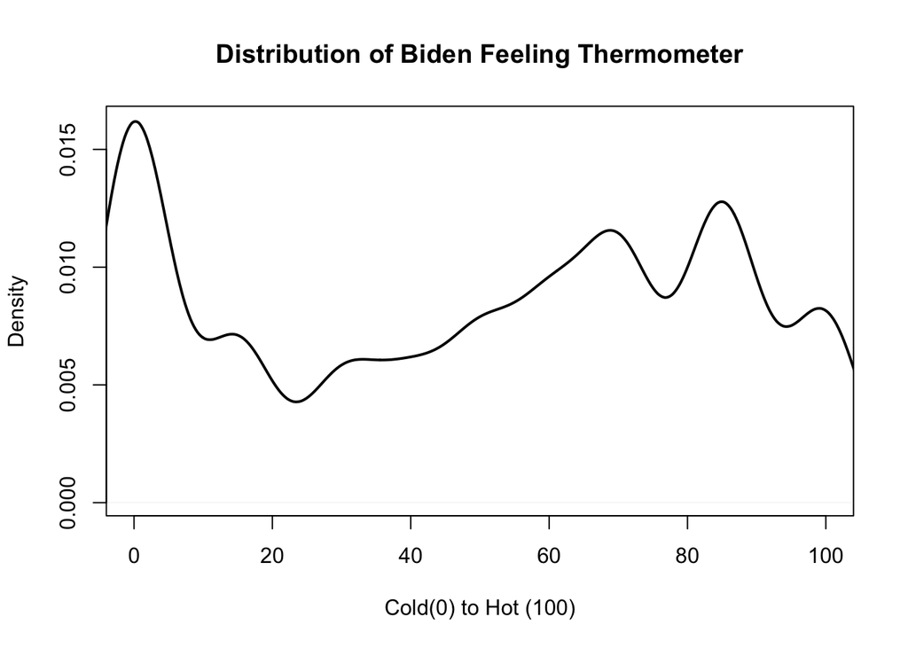

#### Trust

I use another variable to measure the trust a respondant feels towards the government. This question asks respondents “How often do you trust government in Washington to do what is right?” the respondents choose from several answers: “Always”,“Most of the time”,“About half the time”,“Some of the time”, “Never”. The following graph shows the general make up of this data.

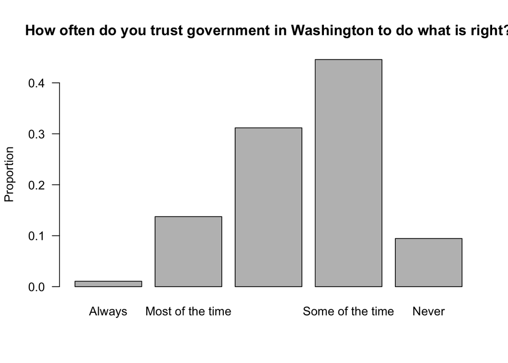

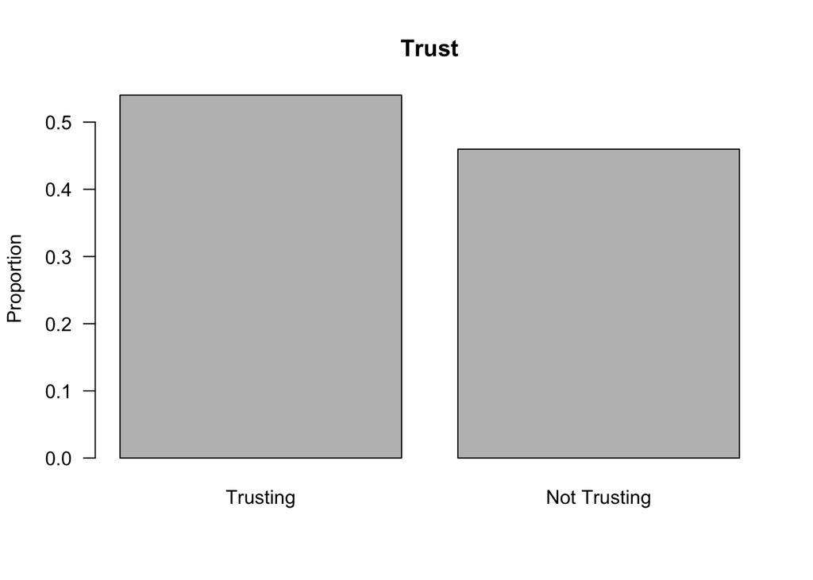

#### Employment

The variable ‘employment’ is built from the survey question “Describe your Employment” where the following are answers:

1. For-profit company or organization
2. Non-profit organization (including tax-exempt and charitable organizations)
3. Local government (for example: city or county school district)
4. State government (including state colleges/universities)
5. Active duty U.S. Armed Forces or Commissioned Corps
6. Federal government civilian employee
7. Owner of non-incorporated business, professional practice, or farm
8. Owner of incorporated business, professional practice, or farm
9. Worked without pay in a for-profit family business or farm for 15 hours or more per week

I have created a binary from these responses where answers 3,4,5,6 indicate they are employed in the government or “1” and the rest are “0” for non-government employment.

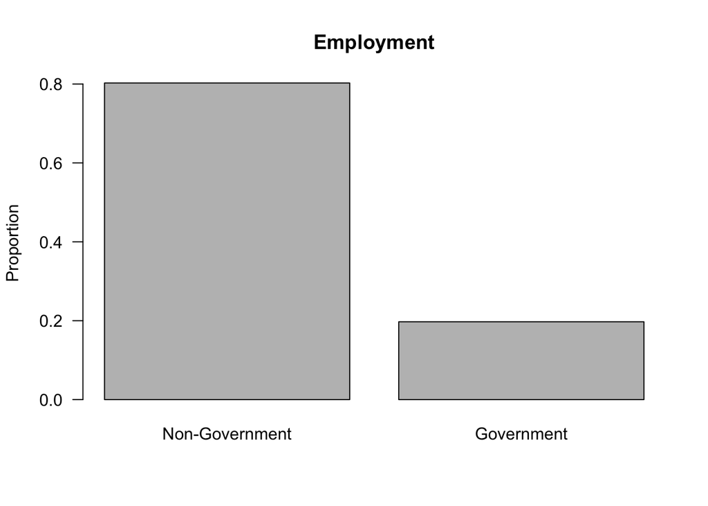

# Difference in Means

A difference in means tells us about the degree of trust and feelings towards Biden. The first table ‘Pooled’ shows the relationship between individuals with high and low trust in the government and their feelings towards Biden. People with low trust averaged a rating of 48.537156 in their feelings towards Biden, where people with high trust averaged a rating of 50.0503538.

Those who worked for the government averaged a rating of 52.4667106 where as those who do not work for the government averaged 48.4102772. Additionally, government workers had a larger difference in means between those classified as low or high trust than with non government workers.

The final boxplot illustrates the feeling themometer in relation to the variable trust before it was coded into a binary variable. This allows us to see the range of responses per trust category. At first glance there is not a clear correlation betwen feelings towards Biden and trust, expecially when we see there is a higher mean in the “sometimes” category than in the “always” category.

#### Feeling Themometer Rankings

| Labels | Government Workers | Non Government Workers | Pooled |
| --- | --- | --- | --- |
| **Average** | 52.4667106 | 48.4102772 | 49.237469 |
| **High Trust** | 54.7088792 | 48.8956679 | 50.0503538 |
| **Low Trust** | 50.5108959 | 47.9533373 | 48.537156 |

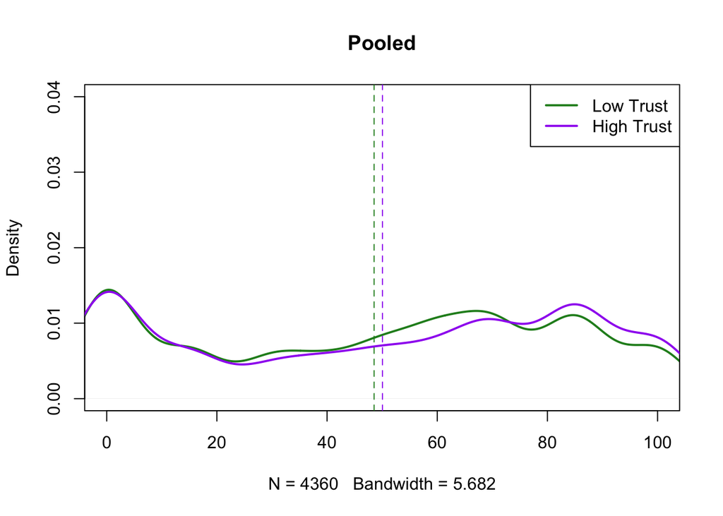

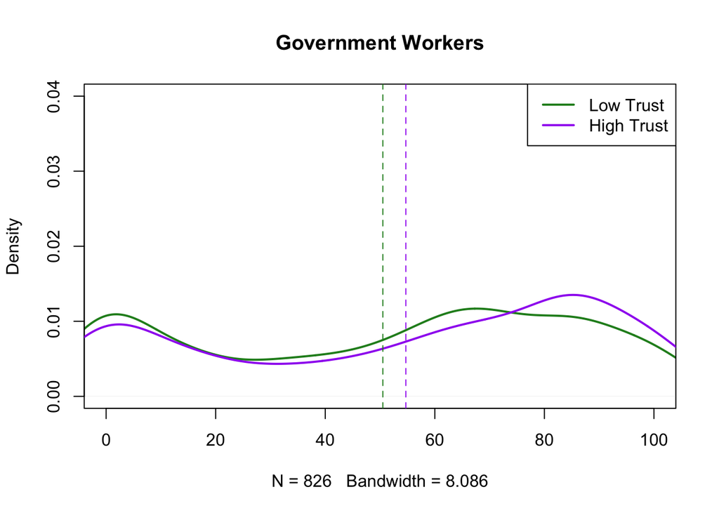

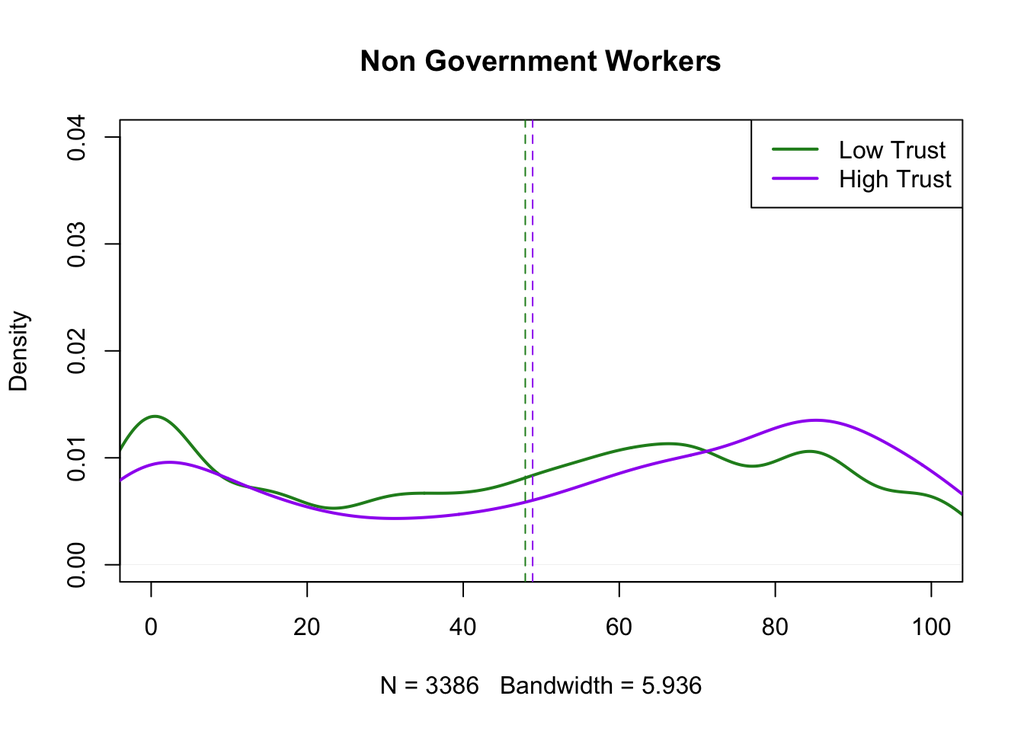

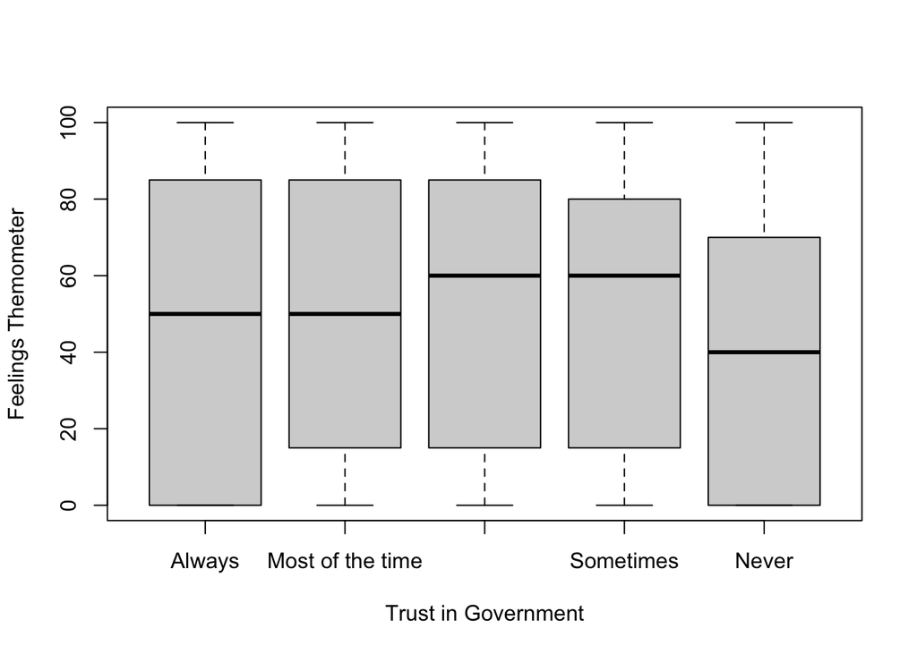

# Regression Analysis

While the previous graphs show us that there some differences in feelings and trust between government and non government workers, they have done little to solidify causality. The previous graphs showed us that on average, government workers rank higher on the feeling thermometer than those who do not work for the government, but it did not assess if trust caused this difference.

For this and the following models I am using the binary variable for trust and employment as discussed prior. I am also clustering the variables by state. This is because some states may be more mobilized to vote, or recieve more media attention depending on how they impact the electoral college, thus errors we make in this regression might be highly correlated to the state.